# R Markdown Centered Data Analysis Workflow

(bonus: how to use Python in R Markdown using reticulate)

2019-10-16 (updated 2019-10-21)

# 1 Introduction

This document describes a data analysis project workflow that uses an R Markdown as a summary (home?) document in which codes written in R and Python are run and findings/narratives follow immediately after each code execution. For general information on R Markdown, see [here](https://rmarkdown.rstudio.com/). For syntax, see [cheatsheet](https://www.rstudio.com/wp-content/uploads/2015/02/rmarkdown-cheatsheet.pdf).

R Markdown can be used to generate a (portable) document that includes,

- Codes: not just of R, but also other languages as well (e.g., Python)
- Tables/plots: output from source codes
- Narratives/findings: narratives documenting quick findings

Therefore, I think it’s a great way to document progress/findings of a data analysis project. (NOTE: maybe add pros and cons of using Rmd vs. Jupyter Notebook)

# 2 Pre-requisites

- Need to have [pandoc](https://pandoc.org) installed.
- Need to have several latest R packages installed: e.g., rmarkdown, reticulate (to use Python)

# 3 Examples

For both R and Python, this document will show examples of working with

- small code snippets embedded within Rmd document
- import/source functions defined in separate scripts then use them within Rmd document
- execute/source separate script files to show outputs from corresponding scripts

In this workflow, I find it helpful to have at least 3 different vim/REPL paired sessions open:

- vim/Rmd for the source .Rmd editing and an interactive R session (let’s call it session “Rmd”)
- vim/R for .R script file editing and an interactive R session (let’s call it session “R”)
- vim/Py for .py script file editing and an interactive Python session (let’s call it session “Python”)

## 3.1 Working with R codes

```r
# R set up (later, there is a separate python set up chunk)

library(ggplot2)
library(dplyr)
library(uncmbb)
library(reticulate) # for Python

# need to specify Python location if planning to use python
# note use_python is an R function, so need to be used in R chunk, not the python one
use_python(python3_path) # python3_path is defined in my .Rprofile
```

### 3.1.1 Running R code snippets within Rmd document directly

We can run simple R code snippets like below.

```r
head(iris)
```

```
##   Sepal.Length Sepal.Width Petal.Length Petal.Width Species
## 1          5.1         3.5          1.4         0.2  setosa
## 2          4.9         3.0          1.4         0.2  setosa
## 3          4.7         3.2          1.3         0.2  setosa
## 4          4.6         3.1          1.5         0.2  setosa
## 5          5.0         3.6          1.4         0.2  setosa
## 6          5.4         3.9          1.7         0.4  setosa
```

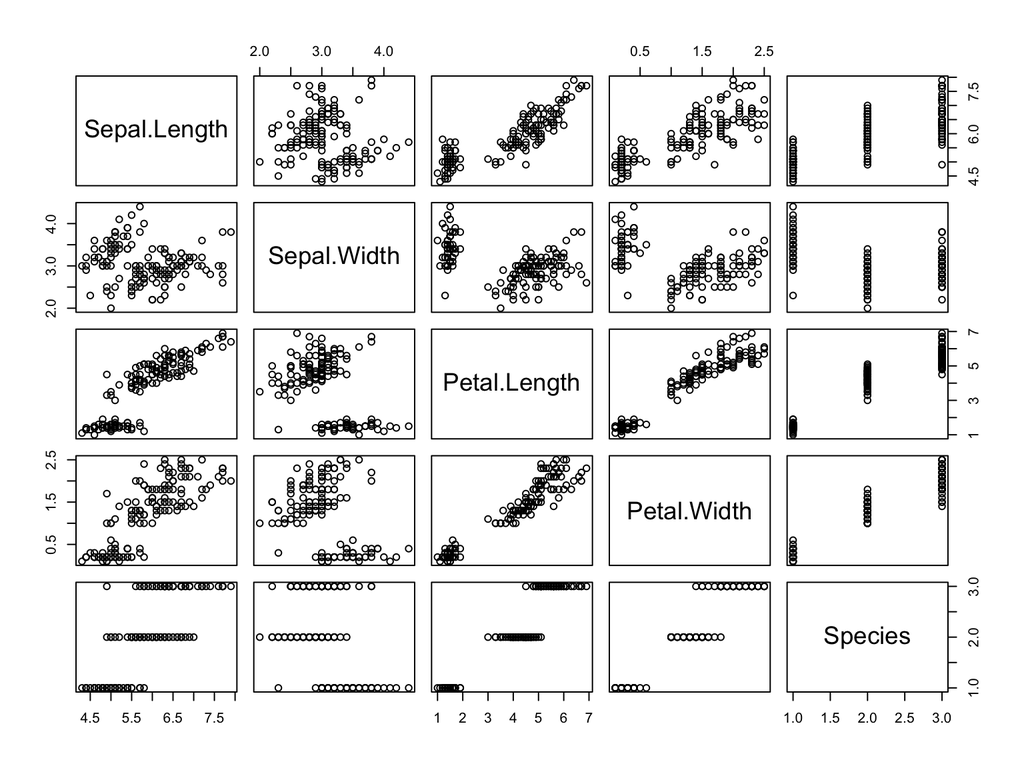

```r
plot(iris)
```

- Note that `print` command was not needed to actually print output of the head and plot commands

When some R packages are needed, best practice is to load them in setup chunk, generally found in the beginning of the Rmd document.

```r
# Using public and personal R packages: load them in setup chunk in the beginning

df <- rbind(unc %>% mutate(school = "UNC"), duke %>% mutate(school = "Duke"))
df <- df %>% dplyr::filter(Type == "NCAA") %>%
             count(school, Result)
head(df)
```

```
## # A tibble: 4 x 3
##   school Result     n
##   <chr>  <chr>  <int>
## 1 Duke   L         37
## 2 Duke   W        111
## 3 UNC    L         43
## 4 UNC    W        122
```

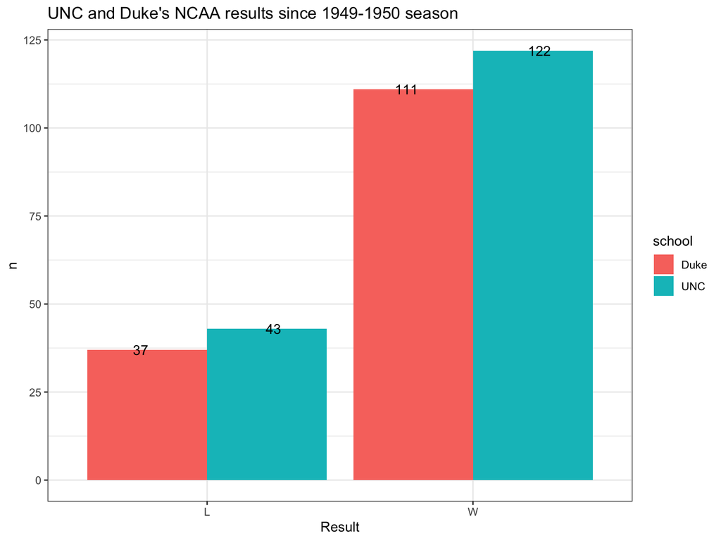

```r
df %>%  ggplot(aes(x = Result, y = n)) +
        geom_bar(aes(fill = school), stat = "identity", position = "dodge") +
        geom_text(aes(group = school, label = n), position = position_dodge(width = 1)) +
        labs(title = "UNC and Duke's NCAA results since 1949-1950 season") +
        theme_bw()
```

- Again, output from `head` and `ggplot` commands were displayed without manual printing.

Objects from above R code snippets can be accessed/used throughout this Rmd document, typically when describing the findings from the snippet. E.g., below findings are calculated inline using objects from above chunk.

Since 1949-1950 season,

- UNC has played total 165 games and won 122 games, and lost 43.
- Duke has played total 148 games and won 111 games, and lost 37.

Findings follow:

- Note again that if snippets are run within Rmd, then no manual `print` command is needed to print plot.
- The home (Rmd) document can become clogged easily.

So we’ve seen how we can use R code snippets in Rmd document, which can be effective for small operations. For more complex operations that require a bit more lines of codes, working directly with code snippets within Rmd document may not be ideal for various reasons. In this case, we can save those (many) lines of codes in separate script files, then source them in Rmd document. First, a hybrid of the two is using functions defined in a separate R script file in the home (Rmd) document.

### 3.1.2 Importing functions from R script files then use them within Rmd document

We can source .R scripts within an R chunk and use functions defined in .R scripts. Below, we source R/r_udfs.R file, which has a definition for a function called `hello`, and we can use it in subsequent chunks of the home (Rmd) document.

```r
# hello function from R/r_udfs.R
source("R/r_udfs.R")
hello("Jay")
```

```
## [1] "Hello, Jay! 'hello' function is defined in r_udfs.R!"
```

- This allows functions to be defined in another .R script, then used in the home (Rmd) document
- Above example uses only one function from the source R script file, but the chunk can become clogged easily just as in the case of running code snippets directly from the home (Rmd) document.

### 3.1.3 Displaying outputs from R script files within Rmd document

Another common (more realistic?) scenario in data analysis project is to start analysis by reading in data stored in a separate directory (e.g., data/), perform data transformation, then generate some tables/plots.

Below, we source R/src_r_script.R file in an R chunk, which reads in a data, summarizes it, and outputs a table and a plot. While writing the R/src_r_script.R code, I’d made sure each line works as intended from a separate R session. This ensures

- the source script works, and
- the findings/narratives can be added to home (Rmd) document without having to render the whole Rmd document

```r
source("R/src_r_script.R")
```

```
## # A tibble: 14 x 3
##    CHAMPION       COACH                n
##    <fct>          <fct>            <int>
##  1 UCLA           John Wooden         10
##  2 Duke           Mike Krzyzewski      5
##  3 Kentucky       Adolph Rupp          4
##  4 Connecticut    Jim Calhoun          3
##  5 Indiana        Bob Knight           3
##  6 North Carolina Roy Williams         3
##  7 Cincinnati     Ed Jucker            2
##  8 Florida        Billy Donovan        2
##  9 Indiana        Branch McCracken     2
## 10 Louisville     Denny Crum           2
## 11 North Carolina Dean Smith           2
## 12 Oklahoma State Henry Iba            2
## 13 San Francisco  Phil Woolpert        2
## 14 Villanova      Jay Wright           2
```

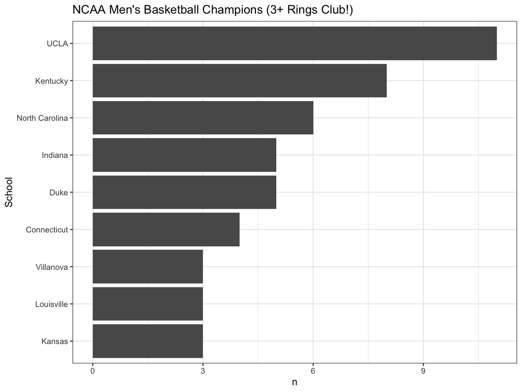

Findings/narratives from the above R script follow immediately, and also more importantly without having to render the whole Rmd document, as the source R script was run and output was checked in a separate session (session “R”).

- Note any objects in the R/src_r_script.R that I want to be displayed in the rendered document had to be saved to a variable and printed manually. Without such manual `print` command, the plot wouldn’t display in rendered Rmd document.
- I can’t wait to see how Duke handles coach K’s retirement (when it happens)

## 3.2 Working with Python codes

We can also work with Python codes from within Rmd document, using [reticulate](https://rstudio.github.io/reticulate/) package!

### 3.2.1 Running Python code snippets within Rmd document

```python
import numpy as np
import pandas as pd
from matplotlib import pyplot as plt

x1 = ['a', 'b', 'c', 'c', 'c', 'b', 'b', 'a', 'a', 'c']
x2 = range(10)
y = [True, False, False, False, True, True, True, False, True, False]
df = pd.DataFrame(zip(x1, x2, y), columns = ['x1', 'x2', 'y'])

# View the data frame
df.head()

# View plot
```

```
##   x1  x2      y
## 0  a   0   True
## 1  b   1  False
## 2  c   2  False
## 3  c   3  False
## 4  c   4   True
```

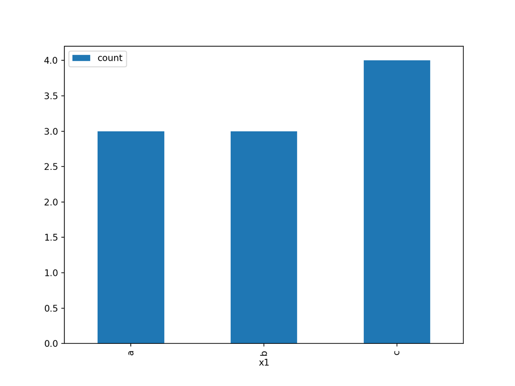

```python
df.groupby('x1').size().reset_index(name = 'count').plot(kind = 'bar', x = 'x1', y = 'count')
plt.show()
```

Finding follows:

- A toy dataframe is hard(er) to put together in Python than in R!

We can check this Python code snippet works from a separate **Python** session (e.g., session ‘Python’).

It’s preferable to first create a setup chunk specifically for Python codes, like that for R.

```python
import os
import sys
import pickle
import numpy as np
import pandas as pd
import importlib
from matplotlib import pyplot as plt
plt.switch_backend('agg') # switch to 'agg' bakend, not X11, in order to disable interactive plot printing during rendering
```

It seems once a python chunk is called, a separate python session is created and maintained throughout the live/active source Rmd document lifetime, therefore allowing the use of imported functions in the subsequent python chunks.

### 3.2.2 Importing functions from Python script files then use them within Rmd document

Just like we used a function defined in a separate R script file in the home (Rmd) document by sourcing the the R script file, we can do a similar thing with Python functions and script files.

```python
# hello function from py/py_udfs.py
from py.py_udfs import *
hello("Jay")
```

```
## Hello, Jay! 'hello' function is defined in py_udfs.py!
```

Note that we imported a Python script file py/py_udfs.py, called a “module” in Python lingo, in the above chunk, and used a function called `hello` defined in it.

### 3.2.3 Displaying outputs from Python script files within Rmd document

Again, a typical data analysis starts by reading in data from a separate directory, performs data transform, and outputs tables/plots.

First I tried using [reticulate::source_python()](https://rstudio.github.io/reticulate/reference/source_python.html) function, but unfortunately, the outputs from the source Python script file didn’t display at all in the rendered document (regardless of backends I used: ‘agg’ and ‘x11’). I have yet to find the answer as to why.

```r
# note language engine here is R, not Python, although we're running Python code!
source_python("py/src_python_script.py") # without "scratch/" in filename
```

On the otherhand, using Python’s `execfile/exec` function within a Python chunk did print the outputs from the Python script files. Below, we are sourcing py/src_python_script.py Python script file in a Python chunk and displays the results from the module. In this sense, Python’s `execfile/exec` function seems to be the closest thing to R’s `source` command

```python
# execfile("py/src_python_script.py") # for Python2
exec(open("py/src_python_script.py").read()) # for Python3
```

```
##           CHAMPION             COACH   n
## 42            UCLA       John Wooden  10
## 7             Duke   Mike Krzyzewski   5
## 16        Kentucky       Adolph Rupp   4
## 32  North Carolina      Roy Williams   3
## 5      Connecticut       Jim Calhoun   3
## 11         Indiana        Bob Knight   3
## 46       Villanova        Jay Wright   2
## 30  North Carolina        Dean Smith   2
## 22      Louisville        Denny Crum   2
## 4       Cincinnati         Ed Jucker   2
## 8          Florida     Billy Donovan   2
## 38   San Francisco     Phil Woolpert   2
## 12         Indiana  Branch McCracken   2
## 36  Oklahoma State         Henry Iba   2
```

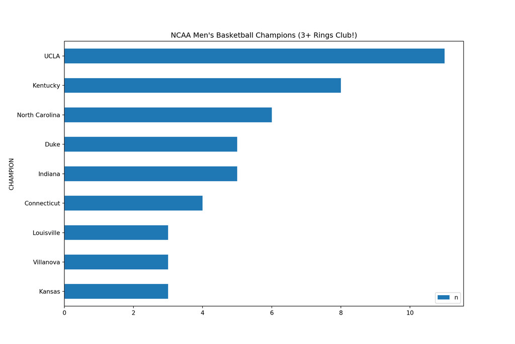

- It’s fun coding in different languages!
- Note slightly different function calls, depending on Python2 and Python3
- While the intended plots are correctly printed on the rendered document, something else happend in the console (interactive session Rmd). Interestingly, while the first output (i.e., a table of coaches with 2+ rings) gets printed in interactive Rmd session, the second output (i.e., a plot of schools with 3+ rings). Instead it prints the following warning:
  - “UserWarning: Matplotlib is currently using agg, which is a non-GUI *backend*, so cannot show the figure.”
  - As long as the rendered document (e.g., html or pdf) contains the outputs (i.e., tables and plots) I wanted, there’s nothing to worry about.
  - I just wanted to call out something new that I had to learn here while it was mentioned: backend. I don’t think I’ve ever had to deal with it before, but it took me a while to finally have all the plots[^1] displayed in the final rendered document, and switching this backend to ‘agg’ (see setup_py chunk) was the magic that did it for me.
- Another important lesson for me was how to `import` Python script files (‘modules’) in another Python file, which deserves its own posting, but suffice to say, it was **different**!

## 3.3 Working with R and Python together

Lastly, we can also run R code snippets using Python objects that are defined earlier in R Markdown (and vice versa, i.e., run Python code snippets using R objects).

### 3.3.1 Using Python objects in R chunk

If you are more comfortable working with ggplot2 in R than say pyplot in Python, then you can use Python objects in an R chunk like below.

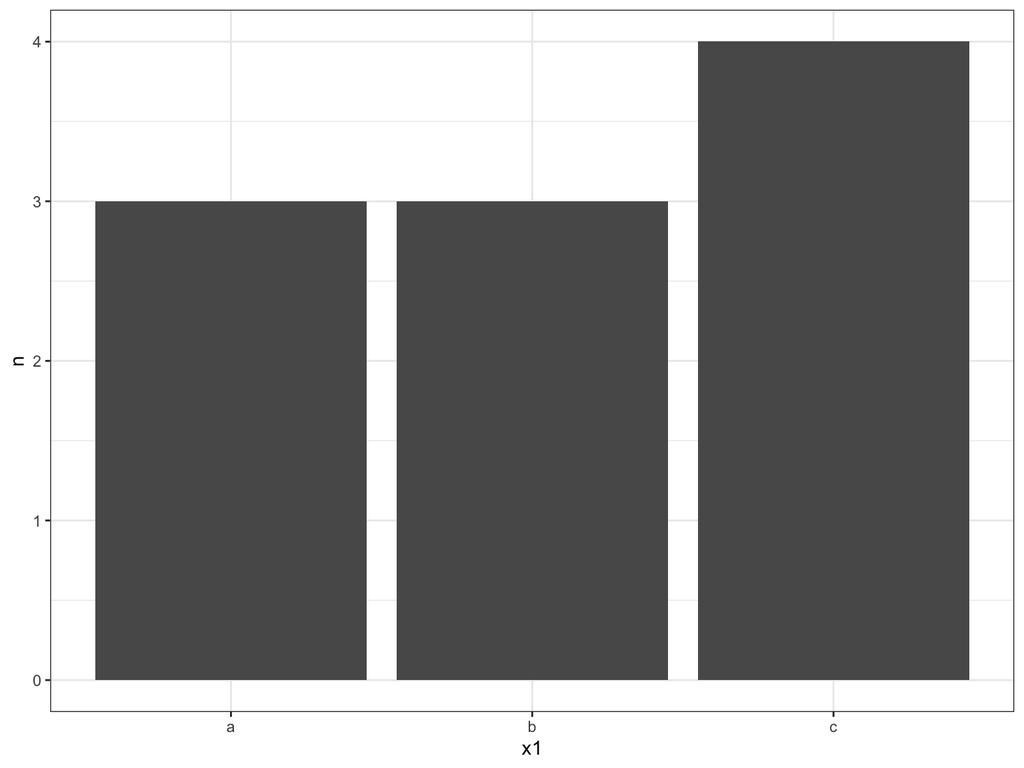

```r
# note 'df' is a Python object defined in the earlier py_snippet_1 chunk
# and is accessible by 'py' with $
df_r = py$df
df_r %>% count(x1) %>%
         ggplot(aes(x = x1, y = n))  +
         geom_bar(stat = "identity") +
         theme_bw()
```

- Note how Python objects are referred to in an R chunk (by py$).

### 3.3.2 Using R objects in Python chunk

The opposite case is to use R objects in a Python chunk.

```python
# note 'unc' is an R object defined in the earlier r_snippet_2 chunk
# and is accessible by 'r' object with a dot
unc_py = r.unc
unc_py.head()
```

```
##   Season   Game_Date Game_Day Type Where    Opponent_School Result    Tm   Opp  OT
## 0   1950  1949-12-01      Thu  REG     H               Elon      W  57.0  39.0  NA
## 1   1950  1949-12-03      Sat  REG     A           Richmond      W  58.0  50.0  NA
## 2   1950  1949-12-05      Mon  REG     A      Virginia Tech      L  48.0  62.0  NA
## 3   1950  1949-12-07      Wed  REG     A       Lenoir-Rhyne      L  78.0  79.0  OT
## 4   1950  1949-12-09      Fri  REG     H  George Washington      L  44.0  54.0  NA
```

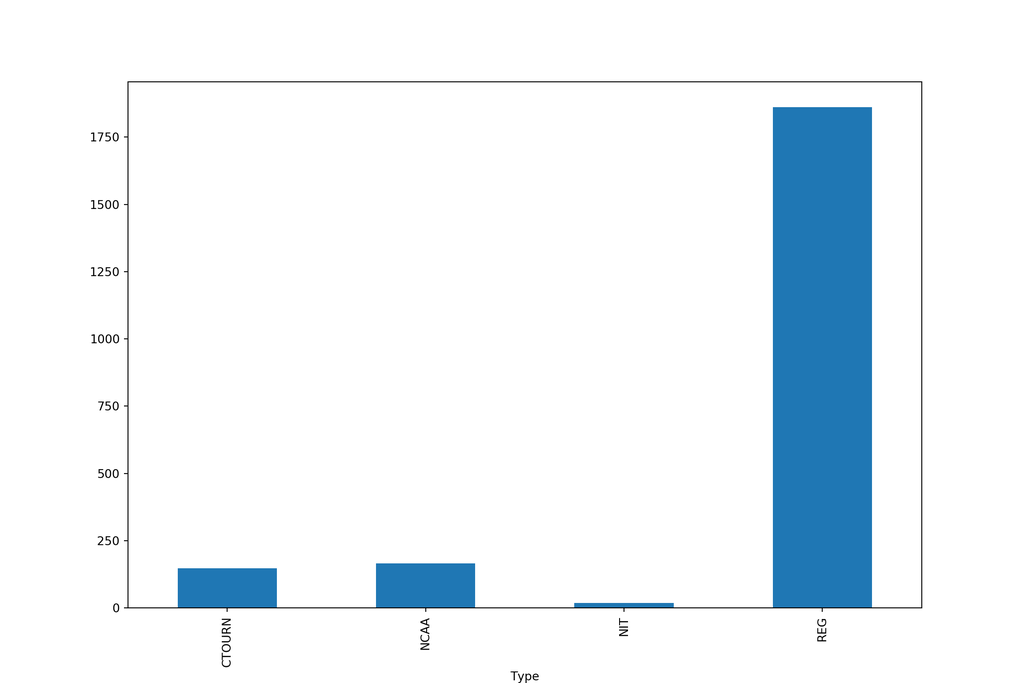

```python
unc_py.groupby('Type').size().plot(kind = 'bar')
plt.show()
```

- Note how R objects are referred to in an Python chunk (by “r.”).
- Interactive checking becomes a bit hard (not sure if it’s even doable), because R (Python) objects have to be read in from Python (R).
  - We can start a Python interpreter using `reticulate::repl_python()` function from an R session (session “Rmd”), but even so, I have yet to find out how to interactively check codes in this context.
- It feels like magic to me, but data conversion between R and Python seems to work just fine.

# 4 Report output

Once all source codes are run and findings/narratives are documented, we can go ahead and generate a summary document. Whether html or pdf, I find having an intermediate summary document of a data analysis project helps me understand the progression/findings of the project more efficiently, especially after some time off the project.

There are several options to view the output document.

1. If no file transfer is required (e.g., all files are already in local machine), open the output using available viewer (e.g., a web browser for html output)
2. If file transfer is needed (e.g., some files are generated in remote machine), then
   - send email from R with attachment (e.g., see [sendmailR](https://cran.r-project.org/web/packages/sendmailR/index.html) package)
   - [SimpleHTTPServer](https://docs.python.org/2/library/simplehttpserver.html) or [http.server](https://docs.python.org/3/library/http.server.html) module from Python

# 5 R Markdown centered data analysis workflow (using Vim)

1. Start three Vim/REPL paired sessions
   - Session Rmd
     - for home (Rmd) document editing and interactive R computing
   - Session R
     - for R script editing and interactive R computing
   - Sesion Py
     - for Py script editing and interactive Python computing
2. Start documenting project progress in session “Rmd”
   - Provide context and describe data, etc.
   - If needed, code directly in the home (Rmd) document
3. If needed, iteratively work on codes (R/Python) in the other sessions (sessions “R” or “Python”), generate plots, and document findings
   - Make sure codes run successfully by checking outputs from each corresponding session (e.g., check R codes work in session “R”, and Python codes work in session “Python”)
   - If findings are worth noting, document them in home (Rmd) document, immediately following code chunks
   - Also document what needs to be done
4. Render to portable document (e.g., html/pdf) and enjoy the output!

When you return to the project after 2-3 days/weeks/months away from it, we now have a summary document that describes what’s done, what needs to be done, how it’s done, etc., all in one home (Rmd) document!

[^1]: It was always plots, not tables, that gave me headaches (e.g., as in, “why are you NOT there?” in the rendered document.